# Project kick-off: Seoul bike rentals

Candidate dataset — topic awaiting group agreement

2026-10-23

## Starting point

This is an initial exploration of a possible dataset, not an agreed project proposal or a final report. The group still needs to agree the topic and check it with the course organiser.

One possible question is: **How do hourly bike rental counts in Seoul vary with time of day, season and recorded weather?** The first step is descriptive: check the records, look at distributions and compare patterns before deciding on a narrower question.

## Data and source

The dataset is **Seoul Bike Sharing Demand**, distributed by the [UCI Machine Learning Repository](https://doi.org/10.24432/C5F62R) under [CC BY 4.0](https://creativecommons.org/licenses/by/4.0/). A copy of the original CSV is in `data/SeoulBikeData.csv`, so knitting this document does not require an internet connection. See data/README.md for the source, units and checksum.

Each row records one hour across the system. The response is the number of bikes rented during that hour, not the number of unique riders. Weather, season, holiday and operating-status variables are also recorded.

## Read and check the records

```r
# The original file uses Latin-1 encoding and a degree symbol in its headers.
bikes_raw <- read_csv(
  "data/SeoulBikeData.csv",
  locale = locale(encoding = "ISO-8859-1"),
  col_types = "cddddddddddccc"
)
stopifnot(ncol(bikes_raw) == 14L, nrow(problems(bikes_raw)) == 0L)

# Use short names, keeping the original units.
names(bikes_raw) <- c(
  "date", "rented_bikes", "hour", "temperature_c", "humidity_pct",
  "wind_speed_ms", "visibility_10m", "dew_point_c", "solar_radiation",
  "rainfall_mm", "snowfall_cm", "season", "holiday", "functioning_day"
)

bikes <- bikes_raw %>%
  mutate(
    date = as.Date(date, format = "%d/%m/%Y"),
    season = factor(season, levels = c("Winter", "Spring", "Summer", "Autumn")),
    holiday = factor(holiday),
    functioning_day = factor(functioning_day)
  )

glimpse(bikes)
```

```
## Rows: 8,760
## Columns: 14
## $ date            <date> 2017-12-01, 2017-12-01, 2017-12-01, 2017-12-01, 2017-~
## $ rented_bikes    <dbl> 254, 204, 173, 107, 78, 100, 181, 460, 930, 490, 339, ~
## $ hour            <dbl> 0, 1, 2, 3, 4, 5, 6, 7, 8, 9, 10, 11, 12, 13, 14, 15, ~
## $ temperature_c   <dbl> -5.2, -5.5, -6.0, -6.2, -6.0, -6.4, -6.6, -7.4, -7.6, ~
## $ humidity_pct    <dbl> 37, 38, 39, 40, 36, 37, 35, 38, 37, 27, 24, 21, 23, 25~
## $ wind_speed_ms   <dbl> 2.2, 0.8, 1.0, 0.9, 2.3, 1.5, 1.3, 0.9, 1.1, 0.5, 1.2,~
## $ visibility_10m  <dbl> 2000, 2000, 2000, 2000, 2000, 2000, 2000, 2000, 2000, ~
## $ dew_point_c     <dbl> -17.6, -17.6, -17.7, -17.6, -18.6, -18.7, -19.5, -19.3~
## $ solar_radiation <dbl> 0.00, 0.00, 0.00, 0.00, 0.00, 0.00, 0.00, 0.00, 0.01, ~
## $ rainfall_mm     <dbl> 0, 0, 0, 0, 0, 0, 0, 0, 0, 0, 0, 0, 0, 0, 0, 0, 0, 0, ~
## $ snowfall_cm     <dbl> 0, 0, 0, 0, 0, 0, 0, 0, 0, 0, 0, 0, 0, 0, 0, 0, 0, 0, ~
## $ season          <fct> Winter, Winter, Winter, Winter, Winter, Winter, Winter~
## $ holiday         <fct> No Holiday, No Holiday, No Holiday, No Holiday, No Hol~
## $ functioning_day <fct> Yes, Yes, Yes, Yes, Yes, Yes, Yes, Yes, Yes, Yes, Yes,~
```

```r
quality_checks <- bikes %>%
  summarise(
    records = n(), days = n_distinct(date),
    first_date = min(date), last_date = max(date),
    missing_entries = sum(is.na(pick(everything()))),
    duplicate_date_hours = n() - n_distinct(date, hour)
  )
quality_checks
```

```
## # A tibble: 1 x 6
##   records  days first_date last_date  missing_entries duplicate_date_hours
##     <int> <int> <date>     <date>               <int>                <int>
## 1    8760   365 2017-12-01 2018-11-30               0                    0
```

```r
bikes %>% summarise(across(everything(), ~ sum(is.na(.x))))
```

```
## # A tibble: 1 x 14
##    date rented_bikes  hour temperature_c humidity_pct wind_speed_ms
##   <int>        <int> <int>         <int>        <int>         <int>
## 1     0            0     0             0            0             0
## # i 8 more variables: visibility_10m <int>, dew_point_c <int>,
## #   solar_radiation <int>, rainfall_mm <int>, snowfall_cm <int>, season <int>,
## #   holiday <int>, functioning_day <int>
```

```r
stopifnot(
  nrow(bikes) == 8760L, n_distinct(bikes$date) == 365L,
  sum(is.na(bikes)) == 0L, !anyDuplicated(bikes[c("date", "hour")]),
  all(bikes$hour %in% 0:23),
  all(bikes$rented_bikes >= 0),
  all(bikes$rented_bikes == floor(bikes$rented_bikes)),
  all(bikes$humidity_pct >= 0 & bikes$humidity_pct <= 100),
  all(bikes$rainfall_mm >= 0 & bikes$snowfall_cm >= 0)
)
```

There are 8760 hourly records covering 1 December 2017 to 30 November 2018. No missing entries or duplicate date-hour combinations were found. The dates are read as day/month/year: reading `01/12/2017` as 12 January would put the records in the wrong order.

### Zero rentals and operating status

```r
bikes %>%
  group_by(functioning_day) %>%
  summarise(hours = n(), zero_rental_hours = sum(rented_bikes == 0),
            mean_rentals = mean(rented_bikes), .groups = "drop")
```

```
## # A tibble: 2 x 4
##   functioning_day hours zero_rental_hours mean_rentals
##   <fct>           <int>             <int>        <dbl>
## 1 No                295               295           0
## 2 Yes              8465                 0         729.
```

```r
bikes_active <- bikes %>% filter(functioning_day == "Yes")
```

All 295 non-operating hours have zero rentals, while none of the 8465 operating hours do. A recorded zero is not a missing value, and zero rentals during a closure do not measure how many people wanted to rent a bike. The original records are retained in `bikes`. The following comparisons use `bikes_active` and describe rentals while the system was operating.

## Distribution of rental counts

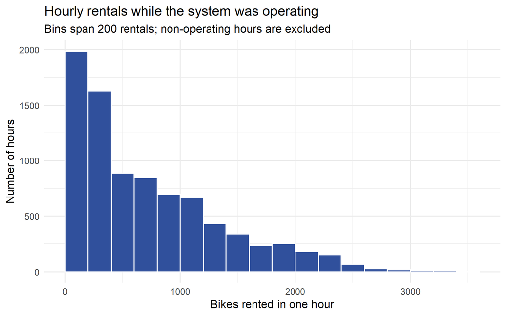

```r
ggplot(bikes_active, aes(x = rented_bikes)) +
  geom_histogram(binwidth = 200, boundary = 0,
                 fill = "#30509C", color = "white") +
  labs(title = "Hourly rentals while the system was operating",
       subtitle = "Bins span 200 rentals; non-operating hours are excluded",
       x = "Bikes rented in one hour", y = "Number of hours")
```

```r
bikes_active %>% summarise(
  mean_rentals = mean(rented_bikes), median_rentals = median(rented_bikes),
  minimum = min(rented_bikes), maximum = max(rented_bikes)
)
```

```
## # A tibble: 1 x 4
##   mean_rentals median_rentals minimum maximum
##          <dbl>          <dbl>   <dbl>   <dbl>
## 1         729.            542       2    3556
```

The distribution is right-skewed. A few busy hours have much higher counts than most hours, so the mean and median give different summaries.

## Time of day and season

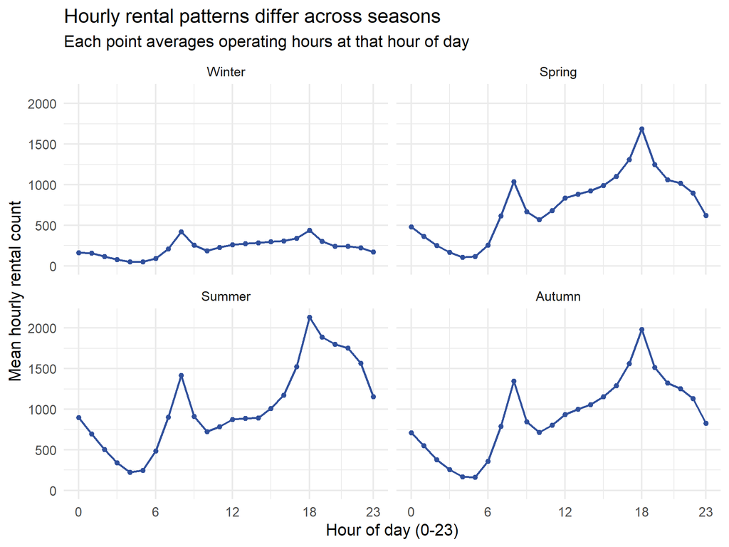

```r
hourly_pattern <- bikes_active %>%
  group_by(season, hour) %>%
  summarise(hours = n(), mean_rentals = mean(rented_bikes), .groups = "drop")

ggplot(hourly_pattern, aes(x = hour, y = mean_rentals)) +
  geom_line(color = "#30509C", linewidth = 0.8) +
  geom_point(color = "#30509C", size = 1.5) +
  facet_wrap(~ season, ncol = 2) +
  scale_x_continuous(breaks = c(0, 6, 12, 18, 23)) +
  scale_y_continuous(limits = c(0, NA)) +
  labs(title = "Hourly rental patterns differ across seasons",
       subtitle = "Each point averages operating hours at that hour of day",
       x = "Hour of day (0-23)", y = "Mean hourly rental count")
```

```r
season_summary <- bikes_active %>%
  group_by(season) %>%
  summarise(hours = n(), mean_rentals = mean(rented_bikes),
            median_rentals = median(rented_bikes), .groups = "drop")
season_summary
```

```
## # A tibble: 4 x 4
##   season hours mean_rentals median_rentals
##   <fct>  <int>        <dbl>          <dbl>
## 1 Winter  2160         226.           203
## 2 Spring  2160         746.           599
## 3 Summer  2208        1034.           906.
## 4 Autumn  1937         924.           856
```

Winter has the lowest mean hourly count, about 226 rentals, compared with about 1034 in summer. Across operating hours overall, 18:00 has the highest mean. There is also a morning rise. These timings are consistent with commuting, but the data do not tell us why people travelled. Season, weather and daily routines may all contribute to the pattern.

## Temperature and recorded rentals

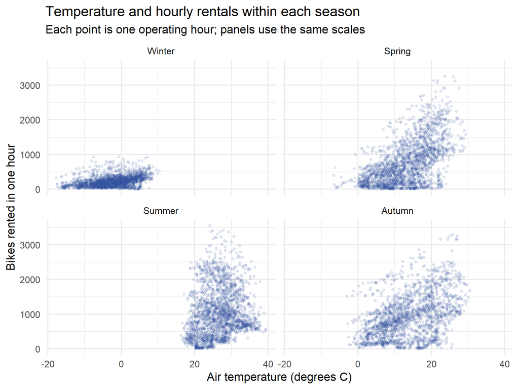

```r
ggplot(bikes_active, aes(x = temperature_c, y = rented_bikes)) +
  geom_point(alpha = 0.12, size = 1, color = "#30509C") +
  facet_wrap(~ season, ncol = 2) +
  labs(title = "Temperature and hourly rentals within each season",
       subtitle = "Each point is one operating hour; panels use the same scales",
       x = "Air temperature (degrees C)", y = "Bikes rented in one hour")
```

Warmer hours often have more recorded rentals, especially when comparing winter with the warmer seasons, but counts vary widely at similar temperatures. This is observational data. Temperature is related to season and time of day, so the plot does not show that raising temperature causes more rentals. The busiest hours also do not necessarily occur at the highest temperatures.

## Questions for the next group discussion

- Is this a dataset the whole group wants to investigate? Check the choice with the course organiser before treating it as final.
- Would comparing hourly patterns on holidays and other days make a more focused question? Check the number of days in each group first.
- Do temperature patterns remain when comparing the same season and hour?
- How should closures be reported alongside the analysis of operating hours?

These records cover one city and one year. They are adjacent observations over time, not independent random samples of people. No causal claim or significance test is made here, and the patterns should not be presented as representative of every city or year.

## Work completed and AI use

The raw data have been saved, checked and plotted. The four-person group has been confirmed. The candidate topic still needs group agreement; repository access is recorded separately in repository-status.md. Final report and presentation files remain course templates for later work.

ChatGPT helped prepare this initial exploration, the R code and the written descriptions. The code was executed, and the counts and numerical summaries were checked in R. The group should review the code and conclusions before using this candidate for the project.